# Student Number: 2640942

Word Count: 3378 (excluding reference list)

An Investigation Into The Impacts Of COVID-19 on New York City Taxi Data

## Introduction

Cities have been a discussion topic for network analysts for the past century, how they interact with each other, why certain cities are connected, and why certain links form between certain groups. Urban cities are a point of interest for network analysts due to their ever-growing nature which increases the different networks within a city (Batty, 2013). A network refers to the interaction between nodes and edges, an example of this is different city destinations (nodes) and the edges would be the number of transports between them. Networks can be influenced by a wide range of variables, for example, Fang et al 2020 presents how spatial link intensity is important when discussing how agglomeration can impact the business hubs within a city and how this interacts with other hubs (Fang et al., 2020). Networks can also be altered by different variables such as weather, time of year and even the time of day.

This report will investigate the Network Analysis of the New York Taxi System, focusing on the Yellow Taxi. Founded in 1912 The New York Taxi System is a fundamental part of New York and is how many commuters get around the city (Ulak, Yazici and Aljarrah, 2020). The New York Taxi System can reflect the environment around it, for example, if there are fewer trips during the day this could suggest that it is a weekday or a less busy day. The New York Taxi System data is increasingly important with the rise in people conforming to the use of Uber as it is viewed as more ‘convenient’ (Willis and Tranos, 2021), this data can reflect the impact Uber and Lyft are having and how the network is changing.

This report will focus on the differences in the New York Yellow Taxi Data set before, during and post-COVID-19. By visualising the differences in the taxi data at each of those times it can present whether there are certain differences in the New York Taxi Data, whether any new hubs and clustering have emerged from this and how significant this is. This report will include the aims of this project as well as a literature review explaining different theories, the methods used, the results found and a discussion of the data as to why this is significant.

#### Aims And Objectives:

- To understand the influence COVID-19 has had on the New York Yellow Taxi System
- To construct spatial networks of the NewYork Yellow Taxi system, with the nodes being the different drop-off and pick-up points.
- To Discuss why the New York Yellow Taxi System is so significant.

## Literature Review

#### Spatial Network Analysis

Spatial Networks are becoming increasingly important when studying network analysis and when looking into urban studies. There has been an increasing interest in this since the publication of Sassen’s ‘The Global city` (Pflieger and Rozenblat, 2010) which presents the idea of how significant flows are between and within cities are and how there can be issues because of this. Pflieger and Rozenblat in particular present the disparity between urban networks and social networks, unlike the traditional social network where it is believed that everything is interconnected, Pflieger and Rozenblat argue that urban networks are different. Instead, these networks connect only to particular networks which serve a distinct purpose for example business hubs or areas of stores. These networks can be influenced on an individual level as well as on a larger scale for example a corporation moving areas. New spatial hubs can also emerge which can affect a network and can even create a whole new network which can be linked in between. An example of this is if a big company such as Deloitte had multiple offices in London but then opened one in Manchester, the movement of one of these ‘nodes’ expands the network and allows for new clusters to arrive as agglomeration can occur. Agglomeration refers to nodes which are clustered together which are benefiting from being close together for example business hubs (Johansson and Quigley, 2004). Spatial Networks can be measured by different variables for example the degree of centrality, betweenness, and clustering. These measures will be explained later in the report. Similar studies have been conducted before to understand commuting flows within major cities, for example, Hamedmoghadam-Rafati et al (2017) researched the New York Taxi Trips, this research adopts an approach where they developed a large-scale mobility network which was weighted and directed(Hamedmoghadam-Rafati et al., 2017). It is important to understand that these network systems are significant and being able to understand the location of the clusters allows for planners to use this information to adapt future transport links.

#### The importance of the New York Taxi System

The New York Taxi System is a fundamental aspect of New York. Not only from a tourist point of view is it an iconic part of New York history, but it also helps many people from day to day to get to where they need to be. For example, in reference to urban mobility on peak days New York Yellow Taxis can accumulate over 450,000 trips a day (N. Ferreira et al., 2013). This can result in thousands of different locations being connected all over. Although there are arguments about what will happen to New York Taxis, as with an increase in external taxi companies such as Uber and Lyft there has been a pull away from the traditional yellow cabs (Willis and Tranos, 2021). Furthermore, it is significant to understand the New York Taxi System and its role in urban mobility. The industry itself brings in around 30% of fares paid by all passengers using different forms of taxi systems and even more than 40% in the area of Manhattan (Gandhi, Gorod and Sauser, 2011). Although there are other forms of transport which are significant to New York such as the subway and bus systems, the yellow cab network represents the significant hubs of New York City. Key hubs of New York include Manhattan and JFK. When going through this investigation it is important to keep the significance of the New York Taxi system in mind and how it helps the mobility of the city even though there are other forms of transport.

#### The Impact Of Covid-19 On Transport Systems

COVID-19 had a detrimental impact on various networks, even 5 years on, the effects of COVID-19 have a lasting impact on our networks. Transport networks took one of the hardest hits. This was due to a decrease in people travelling due to travel restrictions, in particular, travel to JFK would be limited as people would not be travelling back and forth from the area to fly. To this very moment people are still restricting their use of public transport, this is due to the fear of contamination which was present previously during ultimate COVID-19 infections and has carried on to now (Nian et al., 2020). Other issues in the transport sector included that when there was transport available it was still limited as many companies had to enforce social distancing. This has impacted the urban mobility and transport systems as this has reduced the number of passengers for public transport (Abduljabbar, Liyanage and Dia, 2022). However, it could be argued that with a reduction in the use of public transport such as trains and buses, there could be an increase in Taxi trips instead as there are limitations on the number of people you are in contact with (Abduljabbar, Liyanage and Dia, 2022). Transport systems are significant networks as they are directly interlinked with other networks, and they are the backbone of many cities. An example of this is presented in Arimura, 2020 where their investigation found that in Sapporo Japan, the business district population density was reduced by 90% due to travel restrictions (Arimura et al., 2020). Furthermore, since Covid-19 emerged the concept of working from home has become more popular, as a result, a significant amount of people only go to the office one day a week, further hindering transport networks. Overall COVID-19 has had detrimental impacts on transport systems including taxis due to the reduction of people who travel.

## Methods

The data used within this investigation has been obtained from the[TLC Trip Record Data](https://www.nyc.gov/site/tlc/about/tlc-trip-record-data.page), specifically, this report analyses data from three key years, 2017, 2020 and 2023. 2017 was three years before the peak of COVID-19, 2020 was the peak of COVID-19 and 2023 was the time life had returned to somewhat ‘normal’. The month chosen to analyse New York Yellow Taxi Data was July. July was chosen as this is peak tourism season and would show how complex the network system is. This data was then loaded into R and analysed separately to begin with. The data used is formatted as a paraquet, as a result, the function arrow was required to load the data in.

### New York Taxi Data 2017

```r
library(arrow)

taxi_data_2017 <- read_parquet("yellow_tripdata_2017-07 (1).parquet")
```

Once the data has been loaded into the environment, the first few rows of our data will need to be presented to understand the different variables that are present.

```r
head(taxi_data_2017)
```

```
##   VendorID tpep_pickup_datetime tpep_dropoff_datetime passenger_count
## 1        1  2017-07-01 01:06:25   2017-07-01 01:10:50               1
## 2        1  2017-07-01 01:20:04   2017-07-01 01:21:38               2
## 3        1  2017-07-01 01:44:10   2017-07-01 01:59:29               1
## 4        1  2017-07-01 01:07:33   2017-07-01 01:31:30               1
## 5        1  2017-07-01 01:01:17   2017-07-01 01:16:18               1
## 6        1  2017-07-01 01:23:32   2017-07-01 01:43:23               2
##   trip_distance RatecodeID store_and_fwd_flag PULocationID DOLocationID
## 1           1.2          1                  N          249           90
## 2           0.2          1                  N          249          158
## 3           4.3          1                  N          100           45
## 4           8.3          1                  N          138          162
## 5           1.9          1                  N          107          158
## 6           4.7          1                  N          158          263
##   payment_type fare_amount extra mta_tax tip_amount tolls_amount
## 1            1         5.5   0.5     0.5       1.35         0.00
## 2            2         3.0   0.5     0.5       0.00         0.00
## 3            1        15.5   0.5     0.5       3.35         0.00
## 4            1        27.0   0.5     0.5       6.80         5.76
## 5            1        10.5   0.5     0.5       0.00         0.00
## 6            1        17.0   0.5     0.5       3.00         0.00
##   improvement_surcharge total_amount congestion_surcharge airport_fee
## 1                   0.3         8.15                   NA          NA
## 2                   0.3         4.30                   NA          NA
## 3                   0.3        20.15                   NA          NA
## 4                   0.3        40.86                   NA          NA
## 5                   0.3        11.80                   NA          NA
## 6                   0.3        21.30                   NA          NA
```

The taxi data present has multiple columns, however this investigation does not need all of these so instead we split these columns to present what columns we need.

```r
library(knitr)
table_data <- head(taxi_data_2017[, c("tpep_pickup_datetime", "PULocationID", "DOLocationID", "trip_distance")])

kable(table_data,
             caption = "Table 1: The first 6 rows of the reduced taxi data 2017")
```

Table 1: The first 6 rows of the reduced taxi data 2017

| tpep_pickup_datetime | PULocationID | DOLocationID | trip_distance |
| --- | --- | --- | --- |
| 2017-07-01 01:06:25 | 249 | 90 | 1.2 |
| 2017-07-01 01:20:04 | 249 | 158 | 0.2 |
| 2017-07-01 01:44:10 | 100 | 45 | 4.3 |
| 2017-07-01 01:07:33 | 138 | 162 | 8.3 |
| 2017-07-01 01:01:17 | 107 | 158 | 1.9 |
| 2017-07-01 01:23:32 | 158 | 263 | 4.7 |

Before undergoing any form of data analysis, it is important to clean your data and make sure that the data present is correct. In our example, this report found some data from 2008 which was not relevant as this investigation is only dealing with 2017,2020 and 2023. As well as this further minimisation of the data was done as shown below.

```r
str(taxi_data_2017)
```

```
## Classes 'tbl_df', 'tbl' and 'data.frame':    8588486 obs. of  19 variables:
##  $ VendorID             : int  1 1 1 1 1 1 1 1 1 1 ...
##  $ tpep_pickup_datetime : POSIXct, format: "2017-07-01 01:06:25" "2017-07-01 01:20:04" ...
##  $ tpep_dropoff_datetime: POSIXct, format: "2017-07-01 01:10:50" "2017-07-01 01:21:38" ...
##  $ passenger_count      : int  1 2 1 1 1 2 3 1 2 3 ...
##  $ trip_distance        : num  1.2 0.2 4.3 8.3 1.9 4.7 2.3 5.4 1.6 2.6 ...
##  $ RatecodeID           : int  1 1 1 1 1 1 1 1 1 1 ...
##  $ store_and_fwd_flag   : chr  "N" "N" "N" "N" ...
##  $ PULocationID         : int  249 249 100 138 107 158 246 17 170 163 ...
##  $ DOLocationID         : int  90 158 45 162 158 263 162 90 237 90 ...
##  $ payment_type         : int  1 2 1 1 1 1 1 1 2 1 ...
##  $ fare_amount          : num  5.5 3 15.5 27 10.5 17 12 19 8 12 ...
##  $ extra                : num  0.5 0.5 0.5 0.5 0.5 0.5 0.5 0.5 0.5 0.5 ...
##  $ mta_tax              : num  0.5 0.5 0.5 0.5 0.5 0.5 0.5 0.5 0.5 0.5 ...
##  $ tip_amount           : num  1.35 0 3.35 6.8 0 3 2.65 2 0 3.3 ...
##  $ tolls_amount         : num  0 0 0 5.76 0 0 0 0 0 0 ...
##  $ improvement_surcharge: num  0.3 0.3 0.3 0.3 0.3 0.3 0.3 0.3 0.3 0.3 ...
##  $ total_amount         : num  8.15 4.3 20.15 40.86 11.8 ...
##  $ congestion_surcharge : 'vctrs_unspecified' logi  NA NA NA NA NA NA ...
##  $ airport_fee          : 'vctrs_unspecified' logi  NA NA NA NA NA NA ...
```

From the data presented it is shown that the dates are correct and the data can be used.

To create this network, it is crucial to decide what the nodes and edges are within this project. Within this project it was decided that the nodes would be the Pickup (PULocationID) and Drop off (DOLocationID) locations. Whilst the Edges would be the travel between this. To create the nodes, Pick Up and Drop off locations were combined into one vector and then the distinct locations were pulled out of this.

```r
# This combines the nodes together and then distinguishes the different locations
nodes_2017 <- unique(c(taxi_data_2017$PULocationID, taxi_data_2017$DOLocationID))
```

```r
# Identifying the edges within the network by presenting the distance between the drop off locations and pick up locations
edges_2017 <- data.frame(from = paste(taxi_data_2017$PULocationID),
                        to = paste(taxi_data_2017$DOLocationID))
```

For later use when analysing descriptive statistics such as degree centrality and betweeness, the nodes and edges are made into a singular data frame.

```r
library(igraph)
graph_2017 <- graph_from_data_frame(edges_2017, directed = TRUE) #`directed = TRUE' implies that the edges have direction
```

To minimise the data further, this investigation reduced the taxi trips to those under 50 miles which would suggest it is only contained to New York City and the surrounding areas.

```r
taxi_data_2017 <- subset(taxi_data_2017, trip_distance < 50 ) # the subset function allows for subsets to be returned for specific variavkes such as the trip distance under 50 miles
```

To further reduce the data observed in the investigation to obtain a clearer view of the network at hand, this report is primarily using data from the busiest day of July month. The following code represents the method for finding out the busiest day of the month.

```r
taxi_data_2017$tpep_pickup_datetime <- as.POSIXct(taxi_data_2017$tpep_pickup_datetime)

taxi_data_2017$date <- as.Date(taxi_data_2017$tpep_pickup_datetime)

tpd_2017 <- table(taxi_data_2017$date) #tdp_2017 refers to trips per day
```

```r
# This allows for the data to be grouped by their date
library(dplyr)
tpd_2017 <- taxi_data_2017 %>%
  group_by(date) %>%
  summarise(trip_count = n())
```

Using the ggplot2 function, this can present a histogram which shows the different days of July and what days have different amounts of trips. The ggplot2 function was used as this function allows for the user to customise the graph to the extent wanted.

[figure not shown]

Figure 1: Histogram of Taxi Trips per day in July 2017 within New York CIty

```r
# Presenting the busiest days in July 2017 for taxi data

bd_2017 <- tpd_2017 %>%
  arrange(desc(trip_count)) %>%
  head(10)  # Getting the top 10 busiest days

print(bd_2017)
```

```
## # A tibble: 10 × 2
##    date       trip_count
##    <date>          <int>
##  1 2017-07-20     324248
##  2 2017-07-19     324238
##  3 2017-07-13     322628
##  4 2017-07-12     320726
##  5 2017-07-27     315830
##  6 2017-07-21     311803
##  7 2017-07-14     307815
##  8 2017-07-18     307808
##  9 2017-07-28     305706
## 10 2017-07-26     305504
```

As shown in the head above the busiest day of Taxi trips for July 2017 was the 20th. As a result, this investigation for 2017 will be focusing on this date.

```r
# Extracting only the busiest days data from the original 'taxi_data_2017'

busiest_days_2017<- "2017-07-20"

bdd_2017 <- subset(taxi_data_2017, date == busiest_days_2017)
```

Once the day has been chosen, the nodes and edges have to be recreated for the new network analysis.

```r
# Extract pickup(PULocationID) and drop off(DOLocationID) points for the busiest day
nodes_bd_2017 <- unique(cbind(bdd_2017$PULocationID,bdd_2017$DOLocationID))

# Create a unique node identifier for each unique location
nodes_bd_2017 <- unique(data.frame(longitude = nodes_bd_2017[, 1], latitude = nodes_bd_2017[, 2]))
```

```r
# Creating the edges between the busiest day data from pickup and drop off points
edges_bd_2017 <- data.frame(
  from = paste(bdd_2017$PULocationID),
  to = paste(bdd_2017$DOLocationID))
```

The following code makes sure each of the nodes and edges are unique so when the network graph is created the overlap is limited.

```r
# Ensuring that the pickup and dropoff coordinates are unique
bdd_2017$pickup_id <- paste(bdd_2017$PULocationID)
bdd_2017$dropoff_id <- paste(bdd_2017$DOLocationID)

# Combining pickup and dropoff IDs to create unique nodes
nodes_bd_2017 <- unique(cbind(bdd_2017$pickup_id, bdd_2017$dropoff_id))

# This creates a data frame of unique nodes with unique names
nodes_df_2017 <- data.frame(id = unique(c(bdd_2017$pickup_id, bdd_2017$dropoff_id)))
```

```r
# Creating an edge list using the unique identifiers
edges_bd_2017 <- data.frame(
  from = bdd_2017$pickup_id,
  to = bdd_2017$dropoff_id
)
```

Using the new edges and nodes a new network graph can be created which will be presented below.

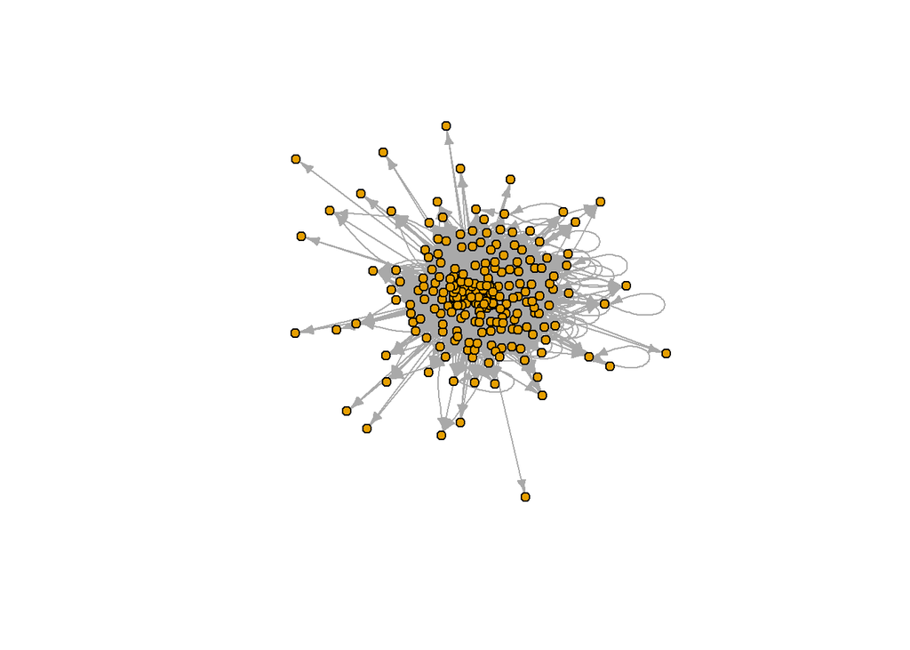

Figure 2: Network Map of New York Taxi Data July 20th 2017

```r
library(igraph)

# Creating the graph
taxi_graph_2017 <- graph_from_data_frame(edges_bd_2017, directed = TRUE, vertices = nodes_df_2017)

# Plotting the network using base R
plot(taxi_graph_2017, vertex.size = 5, vertex.label = NA, edge.arrow.size = 0.5)
```

```r
# Saving the map as a PNG for easier analysis later, can also combine with the other networks.

# Open the PNG device to save the plot
png("nyc_taxi_2017.png", width = 800, height = 600)

# Plotting the map
plot(taxi_graph_2017, vertex.size = 5, vertex.label = NA, edge.arrow.size = 0.5)

# Turn off the device to save the file
dev.off()
```

This method was then followed for the 2020 and 2023 data which can be seen below. The only difference between this data set and the 2020 and 2023 data was they needed to be cleaned as there were dates not relevant to our network present.

### New York 2020 Data

```r
# Importing the 2020 data using the arrow package
library(arrow)

taxi_data_2020 <- read_parquet("yellow_tripdata_2020-07.parquet")
```

```r
head(taxi_data_2020)
```

```
## # A tibble: 6 × 19
##   VendorID tpep_pickup_datetime tpep_dropoff_datetime passenger_count
##      <int> <dttm>               <dttm>                          <dbl>
## 1        1 2020-07-01 01:25:32  2020-07-01 01:33:39                 1
## 2        1 2020-07-01 01:03:19  2020-07-01 01:25:43                 1
## 3        2 2020-07-01 01:15:11  2020-07-01 01:29:24                 1
## 4        2 2020-07-01 01:30:49  2020-07-01 01:38:26                 1
## 5        2 2020-07-01 01:31:26  2020-07-01 01:38:02                 1
## 6        1 2020-07-01 01:09:00  2020-07-01 01:34:39                 1
## # ℹ 15 more variables: trip_distance <dbl>, RatecodeID <dbl>,
## #   store_and_fwd_flag <chr>, PULocationID <int>, DOLocationID <int>,
## #   payment_type <int>, fare_amount <dbl>, extra <dbl>, mta_tax <dbl>,
## #   tip_amount <dbl>, tolls_amount <dbl>, improvement_surcharge <dbl>,
## #   total_amount <dbl>, congestion_surcharge <dbl>, airport_fee <???>
```

```r
# This splits the data so we have access only to the columns we need
library(knitr)
table_data_2020 <- head(taxi_data_2020[, c("tpep_pickup_datetime", "PULocationID", "DOLocationID", "trip_distance")])
kable(table_data_2020,
             caption = "Table 2: The first 6 rows of the reduced taxi data 2020")
```

Table 2: The first 6 rows of the reduced taxi data 2020

| tpep_pickup_datetime | PULocationID | DOLocationID | trip_distance |
| --- | --- | --- | --- |
| 2020-07-01 01:25:32 | 238 | 75 | 1.50 |
| 2020-07-01 01:03:19 | 138 | 216 | 9.50 |
| 2020-07-01 01:15:11 | 230 | 88 | 5.85 |
| 2020-07-01 01:30:49 | 88 | 232 | 1.90 |
| 2020-07-01 01:31:26 | 37 | 17 | 1.25 |
| 2020-07-01 01:09:00 | 140 | 61 | 9.70 |

```r
str(taxi_data_2020)
```

```
## tibble [800,412 × 19] (S3: tbl_df/tbl/data.frame)
##  $ VendorID             : int [1:800412] 1 1 2 2 2 1 2 2 2 2 ...
##  $ tpep_pickup_datetime : POSIXct[1:800412], format: "2020-07-01 01:25:32" "2020-07-01 01:03:19" ...
##  $ tpep_dropoff_datetime: POSIXct[1:800412], format: "2020-07-01 01:33:39" "2020-07-01 01:25:43" ...
##  $ passenger_count      : num [1:800412] 1 1 1 1 1 1 1 1 1 1 ...
##  $ trip_distance        : num [1:800412] 1.5 9.5 5.85 1.9 1.25 ...
##  $ RatecodeID           : num [1:800412] 1 1 1 1 1 1 1 1 1 2 ...
##  $ store_and_fwd_flag   : chr [1:800412] "N" "N" "N" "N" ...
##  $ PULocationID         : int [1:800412] 238 138 230 88 37 140 137 166 239 132 ...
##  $ DOLocationID         : int [1:800412] 75 216 88 232 17 61 260 41 142 249 ...
##  $ payment_type         : int [1:800412] 2 1 2 1 2 1 1 2 1 1 ...
##  $ fare_amount          : num [1:800412] 8 26.5 18.5 8 6.5 30 16.5 7.5 5 52 ...
##  $ extra                : num [1:800412] 0.5 0.5 0.5 0.5 0.5 3 0.5 0.5 0.5 0 ...
##  $ mta_tax              : num [1:800412] 0.5 0.5 0.5 0.5 0.5 0.5 0.5 0.5 0.5 0.5 ...
##  $ tip_amount           : num [1:800412] 0 0 0 2.36 0 ...
##  $ tolls_amount         : num [1:800412] 0 0 0 0 0 0 0 0 0 0 ...
##  $ improvement_surcharge: num [1:800412] 0.3 0.3 0.3 0.3 0.3 0.3 0.3 0.3 0.3 0.3 ...
##  $ total_amount         : num [1:800412] 9.3 27.8 22.3 14.2 7.8 ...
##  $ congestion_surcharge : num [1:800412] 0 0 2.5 2.5 0 2.5 2.5 0 2.5 2.5 ...
##  $ airport_fee          : 'vctrs_unspecified' logi [1:800412] NA NA NA NA NA NA ...
```

```r
# This combines the nodes together and then distinguishes the different locations
nodes_2020 <- unique(c(taxi_data_2020$PULocationID, taxi_data_2020$DOLocationID))
```

```r
# Identifying the edges within the network by presenting the distance between the drop off locations and pick up locations
edges_2020 <- data.frame(from = paste(taxi_data_2020$PULocationID),
                        to = paste(taxi_data_2020$DOLocationID))
```

```r
library(igraph)
graph_2020 <- graph_from_data_frame(edges_2020, directed = TRUE) #`directed = TRUE' implies that the edges have direction
```

```r
taxi_data_2020 <- subset(taxi_data_2020, trip_distance < 50 ) # the subset function allows for subsets to be returned for specific variavkes such as the trip distance under 50 miles
```

```r
# Code to find out the busiest day
taxi_data_2020$tpep_pickup_datetime <- as.POSIXct(taxi_data_2020$tpep_pickup_datetime)

taxi_data_2020$date <- as.Date(taxi_data_2020$tpep_pickup_datetime)

tpd_2020 <- table(taxi_data_2020$date) #tdp_2020 refers to trips per day
```

```r
library(dplyr)
tpd_2020 <- taxi_data_2020 %>%
  group_by(date) %>%
  summarise(trip_count = n())
```

```r
str(tpd_2020)
```

```
## tibble [35 × 2] (S3: tbl_df/tbl/data.frame)
##  $ date      : Date[1:35], format: "2008-12-31" "2009-01-01" ...
##  $ trip_count: int [1:35] 1 1 6 25514 27354 20372 14470 14449 24500 26049 ...
```

```r
# Data needs to be filtered as there was 2008 data present
library(dplyr)

# Defining the desired date range
start_date <- as.Date("2020-07-01")
end_date <- as.Date("2020-07-31")

# Filtering the data
filtered_data_2020 <- tpd_2020 %>%
  filter(date >= start_date & date <= end_date)
```

```r
summary(filtered_data_2020$date)
```

```
##         Min.      1st Qu.       Median         Mean      3rd Qu.         Max.
## "2020-07-01" "2020-07-08" "2020-07-16" "2020-07-16" "2020-07-23" "2020-07-31"
```

```r
unique(filtered_data_2020$date)
```

```
##  [1] "2020-07-01" "2020-07-02" "2020-07-03" "2020-07-04" "2020-07-05"
##  [6] "2020-07-06" "2020-07-07" "2020-07-08" "2020-07-09" "2020-07-10"
## [11] "2020-07-11" "2020-07-12" "2020-07-13" "2020-07-14" "2020-07-15"
## [16] "2020-07-16" "2020-07-17" "2020-07-18" "2020-07-19" "2020-07-20"
## [21] "2020-07-21" "2020-07-22" "2020-07-23" "2020-07-24" "2020-07-25"
## [26] "2020-07-26" "2020-07-27" "2020-07-28" "2020-07-29" "2020-07-30"
## [31] "2020-07-31"
```

[figure not shown]

Figure 3: Histogram of Taxi Trips per day in July 2020 within New York City

```r
# This is the busiest day data for July 2020
bd_2020 <- tpd_2020 %>%
  arrange(desc(trip_count)) %>%
  head(10)  # Get the top 10 busiest days

print(bd_2020)
```

```
## # A tibble: 10 × 2
##    date       trip_count
##    <date>          <int>
##  1 2020-07-31      34540
##  2 2020-07-29      34143
##  3 2020-07-30      33872
##  4 2020-07-28      31953
##  5 2020-07-22      31477
##  6 2020-07-23      30109
##  7 2020-07-21      29470
##  8 2020-07-15      29300
##  9 2020-07-16      29276
## 10 2020-07-24      29189
```

```r
# Extracting the busiest days data
busiest_days_2020<- "2020-07-31"

bdd_2020 <- subset(taxi_data_2020, date == busiest_days_2020)
```

```r
# Extracting pickup and dropoff coordinates for the busiest day
nodes_bd_2020 <- unique(cbind(bdd_2020$PULocationID,bdd_2020$DOLocationID))

# Creating a unique node identifier for each unique location
nodes_bd_2020 <- unique(data.frame(longitude = nodes_bd_2020[, 1], latitude = nodes_bd_2020[, 2]))
```

```r
edges_bd_2020 <- data.frame(
  from = paste(bdd_2020$PULocationID),
  to = paste(bdd_2020$DOLocationID))
```

```r
# Ensuring that the pickup and dropoff coordinates are unique
bdd_2020$pickup_id <- paste(bdd_2020$PULocationID)
bdd_2020$dropoff_id <- paste(bdd_2020$DOLocationID)

# Combining pickup and dropoff IDs to create unique nodes
nodes_bd_2020 <- unique(cbind(bdd_2020$pickup_id, bdd_2020$dropoff_id))

# This creates a data frame of unique nodes with unique names
nodes_df_2020 <- data.frame(id = unique(c(bdd_2020$pickup_id, bdd_2020$dropoff_id)))
```

```r
# Creating an edge list using the unique identifiers
edges_bd_2020 <- data.frame(
  from = bdd_2020$pickup_id,
  to = bdd_2020$dropoff_id
)
```

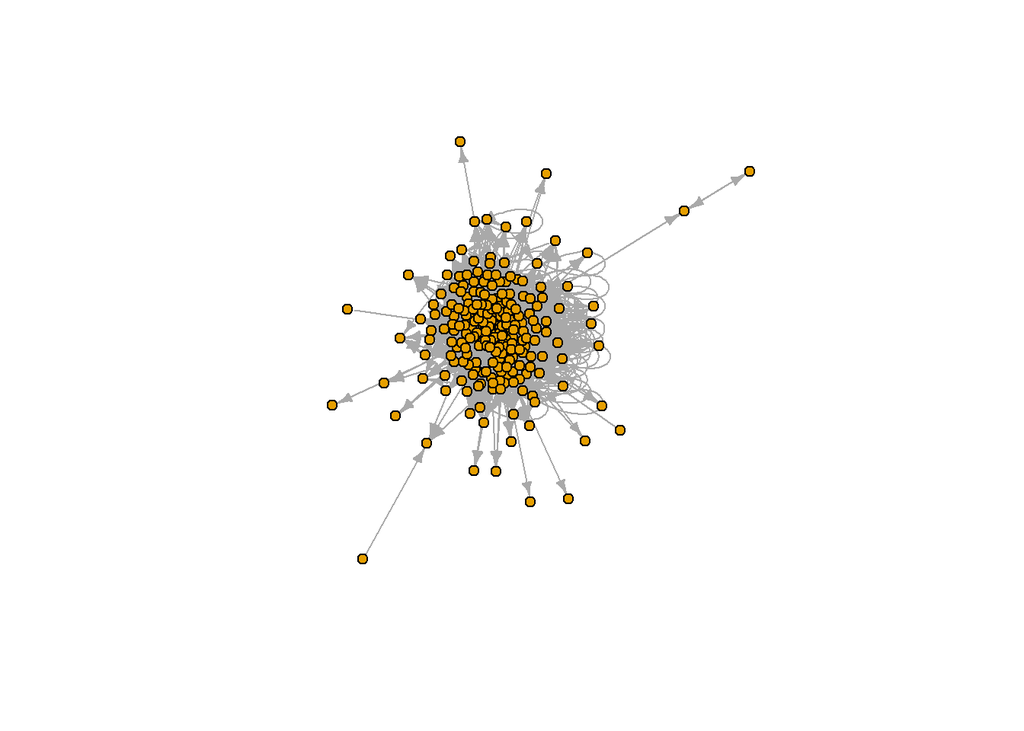

Figure 4: Network Map of New York Taxi Data July 31st 2020

```r
library(igraph)

# Creating the graph
taxi_graph_2020 <- graph_from_data_frame(edges_bd_2020, directed = TRUE, vertices = nodes_df_2020)

# Plotting the network
plot(taxi_graph_2020, vertex.size = 5, vertex.label = NA, edge.arrow.size = 0.5)
```

```r
# Opening the PNG device to save the plot
png("nyc_taxi_2020.png", width = 800, height = 600)

# Plotting the map
plot(taxi_graph_2020, vertex.size = 5, vertex.label = NA, edge.arrow.size = 0.5)

# Turning off the device to save the file
dev.off()
```

### New York Taxi Data 2023

```r
# Importing the 2023 Taxi Data for July
library(arrow)

taxi_data_2023 <- read_parquet("yellow_tripdata_2023-07.parquet")
```

```r
head(taxi_data_2023)
```

```
## # A tibble: 6 × 19
##   VendorID tpep_pickup_datetime tpep_dropoff_datetime passenger_count
##      <int> <dttm>               <dttm>                          <int>
## 1        1 2023-07-01 01:29:59  2023-07-01 01:40:15                 1
## 2        2 2023-07-01 01:03:25  2023-07-01 01:23:44                 1
## 3        2 2023-07-01 01:38:29  2023-07-01 01:48:53                 1
## 4        2 2023-07-01 01:14:16  2023-07-01 01:29:13                 1
## 5        1 2023-07-01 01:11:15  2023-07-01 01:20:47                 0
## 6        2 2023-07-01 01:29:32  2023-07-01 01:54:14                 1
## # ℹ 15 more variables: trip_distance <dbl>, RatecodeID <int>,
## #   store_and_fwd_flag <chr>, PULocationID <int>, DOLocationID <int>,
## #   payment_type <int>, fare_amount <dbl>, extra <dbl>, mta_tax <dbl>,
## #   tip_amount <dbl>, tolls_amount <dbl>, improvement_surcharge <dbl>,
## #   total_amount <dbl>, congestion_surcharge <dbl>, Airport_fee <dbl>
```

```r
# Separating into the columns needed
library(knitr)
table_data_2023 <- head(taxi_data_2023[, c("tpep_pickup_datetime", "PULocationID", "DOLocationID", "trip_distance")])
kable(table_data_2023,
             caption = "Table 3: The first 6 rows of the reduced taxi data 2023")
```

Table 3: The first 6 rows of the reduced taxi data 2023

| tpep_pickup_datetime | PULocationID | DOLocationID | trip_distance |
| --- | --- | --- | --- |
| 2023-07-01 01:29:59 | 140 | 263 | 1.80 |
| 2023-07-01 01:03:25 | 163 | 163 | 2.31 |
| 2023-07-01 01:38:29 | 142 | 262 | 2.36 |
| 2023-07-01 01:14:16 | 68 | 24 | 4.36 |
| 2023-07-01 01:11:15 | 161 | 107 | 1.60 |
| 2023-07-01 01:29:32 | 138 | 186 | 8.67 |

```r
str(taxi_data_2023)
```

```
## tibble [2,907,108 × 19] (S3: tbl_df/tbl/data.frame)
##  $ VendorID             : int [1:2907108] 1 2 2 2 1 2 2 2 1 2 ...
##  $ tpep_pickup_datetime : POSIXct[1:2907108], format: "2023-07-01 01:29:59" "2023-07-01 01:03:25" ...
##  $ tpep_dropoff_datetime: POSIXct[1:2907108], format: "2023-07-01 01:40:15" "2023-07-01 01:23:44" ...
##  $ passenger_count      : int [1:2907108] 1 1 1 1 0 1 1 1 0 3 ...
##  $ trip_distance        : num [1:2907108] 1.8 2.31 2.36 4.36 1.6 8.67 9.11 3.08 1.1 3.88 ...
##  $ RatecodeID           : int [1:2907108] 1 1 1 1 1 1 1 1 1 1 ...
##  $ store_and_fwd_flag   : chr [1:2907108] "N" "N" "N" "N" ...
##  $ PULocationID         : int [1:2907108] 140 163 142 68 161 138 138 166 138 186 ...
##  $ DOLocationID         : int [1:2907108] 263 163 262 24 107 186 230 244 70 24 ...
##  $ payment_type         : int [1:2907108] 1 2 1 1 1 1 1 1 1 1 ...
##  $ fare_amount          : num [1:2907108] 12.1 19.1 13.5 19.8 11.4 38.7 39.4 14.9 7.9 19.8 ...
##  $ extra                : num [1:2907108] 3.5 1 1 1 3.5 6 6 1 7.75 1 ...
##  $ mta_tax              : num [1:2907108] 0.5 0.5 0.5 0.5 0.5 0.5 0.5 0.5 0.5 0.5 ...
##  $ tip_amount           : num [1:2907108] 5.1 0 3.7 4.96 3.25 ...
##  $ tolls_amount         : num [1:2907108] 0 0 0 0 0 6.55 6.55 0 0 0 ...
##  $ improvement_surcharge: num [1:2907108] 1 1 1 1 1 1 1 1 1 1 ...
##  $ total_amount         : num [1:2907108] 22.2 24.1 22.2 29.8 19.6 ...
##  $ congestion_surcharge : num [1:2907108] 2.5 2.5 2.5 2.5 2.5 2.5 2.5 0 0 2.5 ...
##  $ Airport_fee          : num [1:2907108] 0 0 0 0 0 1.75 1.75 0 1.75 0 ...
```

```r
# This combines the nodes together and then distinguishes the different locations
nodes_2023 <- unique(c(taxi_data_2023$PULocationID, taxi_data_2023$DOLocationID))
```

```r
# Identifying the edges within the network by presenting the distance between the drop off locations and pick up locations
edges_2023 <- data.frame(from = paste(taxi_data_2023$PULocationID),
                        to = paste(taxi_data_2023$DOLocationID))
```

```r
library(igraph)
graph_2023 <- graph_from_data_frame(edges_2023, directed = TRUE) #`directed = TRUE' implies that the edges have direction
```

```r
taxi_data_2023 <- subset(taxi_data_2023, trip_distance < 50 ) # the subset function allows for just trips under 50 miles to be extracted
```

```r
taxi_data_2023$tpep_pickup_datetime <- as.POSIXct(taxi_data_2023$tpep_pickup_datetime)

taxi_data_2023$date <- as.Date(taxi_data_2023$tpep_pickup_datetime)

tpd_2023 <- table(taxi_data_2023$date) #tdp_2017 refers to trips per day
```

```r
library(dplyr)
tpd_2023 <- taxi_data_2023 %>%
  group_by(date) %>%
  summarise(trip_count = n())
```

```r
# Seeing if the data is clean for use
str(tpd_2023)
```

```
## tibble [40 × 2] (S3: tbl_df/tbl/data.frame)
##  $ date      : Date[1:40], format: "2002-12-31" "2008-12-31" ...
##  $ trip_count: int [1:40] 1 1 2 41 81233 68466 64528 57449 84842 93041 ...
```

```r
# Cleaning up the data for use by selecting our range of dates
library(dplyr)

# Defining our desired range
start_date <- as.Date("2023-07-01")
end_date <- as.Date("2023-07-31")

# Filtering the data
filtered_data_2023 <- tpd_2023 %>%
  filter(date >= start_date & date <= end_date)
```

```r
summary(filtered_data_2023$date)
```

```
##         Min.      1st Qu.       Median         Mean      3rd Qu.         Max.
## "2023-07-01" "2023-07-08" "2023-07-16" "2023-07-16" "2023-07-23" "2023-07-31"
```

```r
unique(filtered_data_2023$date)
```

```
##  [1] "2023-07-01" "2023-07-02" "2023-07-03" "2023-07-04" "2023-07-05"
##  [6] "2023-07-06" "2023-07-07" "2023-07-08" "2023-07-09" "2023-07-10"
## [11] "2023-07-11" "2023-07-12" "2023-07-13" "2023-07-14" "2023-07-15"
## [16] "2023-07-16" "2023-07-17" "2023-07-18" "2023-07-19" "2023-07-20"
## [21] "2023-07-21" "2023-07-22" "2023-07-23" "2023-07-24" "2023-07-25"
## [26] "2023-07-26" "2023-07-27" "2023-07-28" "2023-07-29" "2023-07-30"
## [31] "2023-07-31"
```

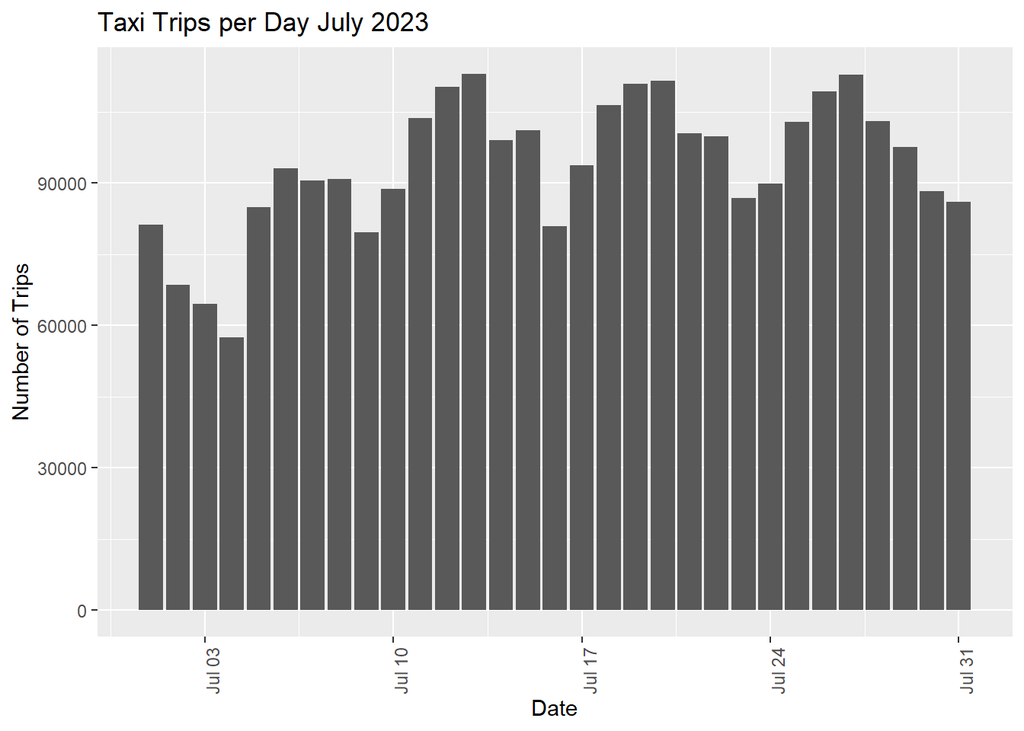

Figure 5: Histogram of Taxi Trips per day in July 2023 within New York City

```r
# Plotting the busiest days
library(ggplot2)
ggplot(filtered_data_2023, aes(x = date, y = trip_count)) +
  geom_bar(stat = "identity") +
  labs(title = "Taxi Trips per Day July 2023", x = "Date", y = "Number of Trips") +
  theme(axis.text.x = element_text(angle = 90, hjust = 1))
```

```r
# Finding what day is the busiest
bd_2023 <- tpd_2023 %>%
  arrange(desc(trip_count)) %>%
  head(10)  # Getting the top 10 busiest days

print(bd_2023)
```

```
## # A tibble: 10 × 2
##    date       trip_count
##    <date>          <int>
##  1 2023-07-13     112971
##  2 2023-07-27     112844
##  3 2023-07-20     111597
##  4 2023-07-19     110931
##  5 2023-07-12     110251
##  6 2023-07-26     109236
##  7 2023-07-18     106352
##  8 2023-07-11     103583
##  9 2023-07-28     103036
## 10 2023-07-25     102852
```

```r
# Defining the busiest day in July 2023
busiest_days_2023 <- "2023-07-13"

bdd_2023 <- subset(taxi_data_2023, date == busiest_days_2023)
```

```r
# Extracting pickup and dropoff coordinates for the busiest day
nodes_bd_2023 <- unique(cbind(bdd_2023$PULocationID,bdd_2023$DOLocationID))

# Creating a unique node identifier for each unique location
nodes_bd_2023 <- unique(data.frame(longitude = nodes_bd_2023[, 1], latitude = nodes_bd_2023[, 2]))
```

```r
edges_bd_2023 <- data.frame(
  from = paste(bdd_2023$PULocationID),
  to = paste(bdd_2023$DOLocationID))
```

```r
# Ensuring that the pickup and dropoff coordinates are unique
bdd_2023$pickup_id <- paste(bdd_2023$PULocationID)
bdd_2023$dropoff_id <- paste(bdd_2023$DOLocationID)

# Combining pickup and dropoff IDs to create unique nodes
nodes_bd_2023 <- unique(cbind(bdd_2023$pickup_id, bdd_2023$dropoff_id))

# This creates a data frame of unique nodes with unique names
nodes_df_2023 <- data.frame(id = unique(c(bdd_2023$pickup_id, bdd_2023$dropoff_id)))
```

```r
# Creating an edge list using the unique identifiers
edges_bd_2023 <- data.frame(
  from = bdd_2023$pickup_id,
  to = bdd_2023$dropoff_id
)
```

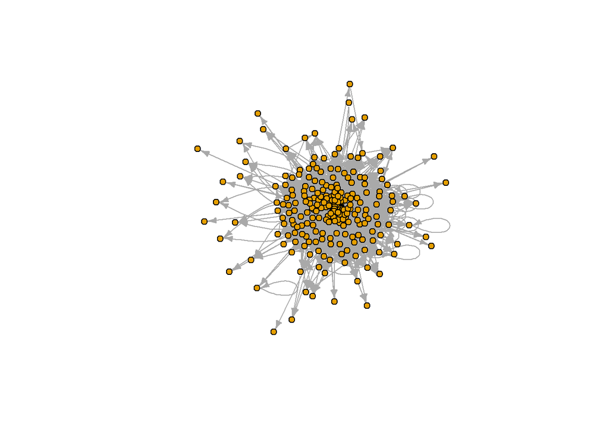

Figure 6: Network Map of New York Taxi Data July 13th 2023

```r
library(igraph)

# Creating the graph
taxi_graph_2023 <- graph_from_data_frame(edges_bd_2023, directed = TRUE, vertices = nodes_df_2023)

# Plotting the network
plot(taxi_graph_2023, vertex.size = 5, vertex.label = NA, edge.arrow.size = 0.5)
```

```r
# Saving the map as a PNG
# Opening the PNG device to save the plot
png("nyc_Taxi_2023.png", width = 800, height = 600)

# Plot the map
plot(taxi_graph_2023, vertex.size = 5, vertex.label = NA, edge.arrow.size = 0.5)

# Turn off the device to save the file
dev.off()
```

To easily compare the data present, the grid function was used to combine all three maps.

```r
library(gridExtra)
library(png)
library(grid)
```

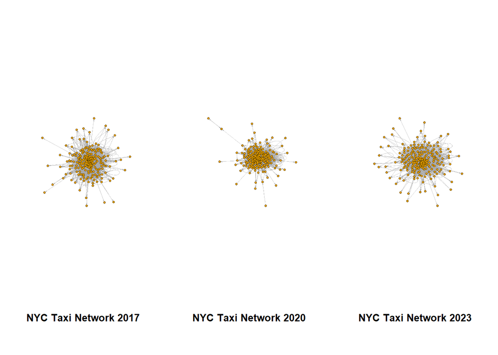

Figure 7: Taxi Network maps from 2017,2020 and 2023 combined to visualise easier

```r
# Loading the images
img_2017 <- readPNG("nyc_Taxi_2017.png")
img_2020 <- readPNG("nyc_Taxi_2020.png")
img_2023 <- readPNG("nyc_Taxi_2023.png")

# Converting them to raster objects
g_2017 <- rasterGrob(img_2017, interpolate = TRUE)
g_2020 <- rasterGrob(img_2020, interpolate = TRUE)
g_2023 <- rasterGrob(img_2023, interpolate = TRUE)

# Creating labels for each plot
label_2017 <- textGrob("NYC Taxi Network 2017", gp = gpar(fontsize = 10, fontface = "bold"))
label_2020 <- textGrob("NYC Taxi Network 2020", gp = gpar(fontsize = 10, fontface = "bold"))
label_2023 <- textGrob("NYC Taxi Network 2023", gp = gpar(fontsize = 10, fontface = "bold"))

# Combining the image and the label into one grob for each year
g_2017_labeled <- arrangeGrob(g_2017, label_2017, ncol = 1, heights = unit(c(10, 1), "cm"))
g_2020_labeled <- arrangeGrob(g_2020, label_2020, ncol = 1, heights = unit(c(10, 1), "cm"))
g_2023_labeled <- arrangeGrob(g_2023, label_2023, ncol = 1, heights = unit(c(10, 1), "cm"))

# Combining the labeled images into a single layout (1 row, 3 columns)
combined_plot <- grid.arrange(g_2017_labeled, g_2020_labeled, g_2023_labeled, ncol = 3)
```

```r
# Saving this image
# Open PNG device to save the plot
png("nyc_Taxi_full.png", width = 800, height = 600)

# Plot the map
combined_plot <- grid.arrange(g_2017_labeled, g_2020_labeled, g_2023_labeled, ncol = 3)
# Turn off the device to save the file
dev.off()
```

### Centrality Measures

Furthermore, once we have investigated all the different network graphs, to further analyse the data at present, the degree centrality other measures will be analysed as follows. Using the data previously collected. Using the Kable function we can present the different variables.

#### Centralities 2017

```r
# Calculating degree centrality
V(graph_2017)$degree <- degree(graph_2017, mode = "all")
V(graph_2017)$in_degree <- degree(graph_2017, mode = "in")
V(graph_2017)$out_degree <- degree(graph_2017, mode = "out")
```

```r
# Calculating betweenness centrality
V(graph_2017)$betweenness <- betweenness(graph_2017, directed = TRUE, normalized = TRUE)
# Calculating closeness centrality
V(graph_2017)$closeness <- closeness(graph_2017, mode = "all", normalized = TRUE)
# Calculating eigenvector centrality
V(graph_2017)$eigenvector <- eigen_centrality(graph_2017, directed = TRUE)$vector
```

```r
# Creating a data frame of node-level measures
node_metrics <- data.frame(
  Degree = V(graph_2017)$degree,        # Degree centrality
  InDegree = V(graph_2017)$in_degree,  # In-degree centrality
  OutDegree = V(graph_2017)$out_degree, # Out-degree centrality
  Betweenness = V(graph_2017)$betweenness, # Betweenness centrality
  Closeness = V(graph_2017)$closeness, # Closeness centrality
  Eigenvector = V(graph_2017)$eigenvector   # PageRank scores
)

# Previewing the data frame
head(node_metrics)
```

```
##   Degree InDegree OutDegree Betweenness Closeness Eigenvector
## 1 317695   140761    176934 0.006169135 0.9489051   0.3439389
## 2 329910   142323    187587 0.007191720 0.9629630   0.4201544
## 3 344052    98342    245710 0.076932719 0.9923664   0.2854493
## 4 383604   182587    201017 0.005588071 0.9352518   0.5035989
## 5 208173    99338    108835 0.005272515 0.9154930   0.2350470
## 6 284938   155394    129544 0.002368433 0.9090909   0.4217185
```

##### Centralities 2020

```r
# Calculating degree centrality
V(graph_2020)$degree <- degree(graph_2020, mode = "all")
V(graph_2020)$in_degree <- degree(graph_2020, mode = "in")
V(graph_2020)$out_degree <- degree(graph_2020, mode = "out")
```

```r
# Calculating betweenness centrality
V(graph_2020)$betweenness <- betweenness(graph_2020, directed = TRUE, normalized = TRUE)
# Calculating closeness centrality
V(graph_2020)$closeness <- closeness(graph_2020, mode = "all", normalized = TRUE)
# Calculating eigenvector centrality
V(graph_2020)$eigenvector <- eigen_centrality(graph_2020, directed = TRUE)$vector
```

```r
# Creating a data frame of node-level measures
node_metrics_2020 <- data.frame(
  Degree = V(graph_2020)$degree,        # Degree centrality
  InDegree = V(graph_2020)$in_degree,  # In-degree centrality
  OutDegree = V(graph_2020)$out_degree, # Out-degree centrality
  Betweenness = V(graph_2020)$betweenness, # Betweenness centrality
  Closeness = V(graph_2020)$closeness, # Closeness centrality
  Eigenvector = V(graph_2020)$eigenvector   # PageRank scores
)

# Previewing the data frame
head(node_metrics_2020)
```

```
##   Degree InDegree OutDegree Betweenness Closeness Eigenvector
## 1  44569    21126     23443 0.005006004 0.8170347  0.52064878
## 2  14638     2594     12044 0.033094790 0.9487179  0.03786147
## 3  20407     9135     11272 0.001368370 0.8274760  0.17991491
## 4   3829     2157      1672 0.005334263 0.7801205  0.03473467
## 5   2135     1526       609 0.001630659 0.7754491  0.01278108
## 6  49208    23094     26114 0.044818048 0.9283154  0.60895315
```

##### Centralities 2023

```r
# Calculating degree centrality
V(graph_2023)$degree <- degree(graph_2023, mode = "all")
V(graph_2023)$in_degree <- degree(graph_2023, mode = "in")
V(graph_2023)$out_degree <- degree(graph_2023, mode = "out")
```

```r
# Calculating betweenness centrality
V(graph_2023)$betweenness <- betweenness(graph_2023, directed = TRUE, normalized = TRUE)
# Calculating closeness centrality
V(graph_2023)$closeness <- closeness(graph_2023, mode = "all", normalized = TRUE)
# Calculating eigenvector centrality
V(graph_2023)$eigenvector <- eigen_centrality(graph_2023, directed = TRUE)$vector
```

```r
# Creating a data frame of node-level measures
node_metrics_2023 <- data.frame(
  Degree = V(graph_2023)$degree,        # Degree centrality
  InDegree = V(graph_2023)$in_degree,  # In-degree centrality
  OutDegree = V(graph_2023)$out_degree, # Out-degree centrality
  Betweenness = V(graph_2023)$betweenness, # Betweenness centrality
  Closeness = V(graph_2023)$closeness, # Closeness centrality
  Eigenvector = V(graph_2023)$eigenvector   # PageRank scores
)

# Previewing the data frame
head(node_metrics_2023)
```

```
##   Degree InDegree OutDegree Betweenness Closeness Eigenvector
## 1 110508    56612     53896 0.018349386 0.8972603   0.4676678
## 2 157942    74670     83272 0.005129515 0.8590164   0.5903313
## 3 168650    78419     90231 0.006197477 0.8762542   0.6435862
## 4 153803    75547     78256 0.016852043 0.9225352   0.5108670
## 5 252476   115609    136867 0.010903685 0.9003436   0.9380132
## 6 140791    37604    103187 0.065640735 0.9739777   0.2775439
```

#### Node Metrics 2017

```r
# Table for 2017 summarising the measurements
library(knitr)
library(kableExtra)

# Creating table
node_metrics %>%
  head(10)%>%
  arrange(desc(Degree)) %>%  # Sorting by degree
  kable(
    format = "html",
    col.names = c("Degree", "In-Degree", "Out-Degree",
                  "Betweenness", "Closeness", "Eigenvector"),
                  caption = "Table 4: Node Metrics for taxi network 2017"
  ) %>%
  kable_styling(full_width = FALSE, bootstrap_options = c("striped", "hover"))
```

Table 4: Node Metrics for taxi network 2017

| Degree | In-Degree | Out-Degree | Betweenness | Closeness | Eigenvector |
| --- | --- | --- | --- | --- | --- |
| 578245 | 287353 | 290892 | 0.0086739 | 0.9774436 | 0.8315496 |
| 447027 | 215020 | 232007 | 0.0046610 | 0.9454545 | 0.6453486 |
| 444083 | 210001 | 234082 | 0.0048814 | 0.9154930 | 0.6123204 |
| 383604 | 182587 | 201017 | 0.0055881 | 0.9352518 | 0.5035989 |
| 344052 | 98342 | 245710 | 0.0769327 | 0.9923664 | 0.2854493 |
| 329910 | 142323 | 187587 | 0.0071917 | 0.9629630 | 0.4201544 |
| 317695 | 140761 | 176934 | 0.0061691 | 0.9489051 | 0.3439389 |
| 284938 | 155394 | 129544 | 0.0023684 | 0.9090909 | 0.4217185 |
| 208173 | 99338 | 108835 | 0.0052725 | 0.9154930 | 0.2350470 |
| 15516 | 13386 | 2130 | 0.0004110 | 0.7202216 | 0.0204088 |

#### Node Metrics 2020

```r
# Table for 2020 summarising the measurement
node_metrics_2020 %>%
  head(10)%>%
  arrange(desc(Degree)) %>%  # Sort by Degree (or any other metric)
  kable(
    format = "html",
    col.names = c("Degree", "In-Degree", "Out-Degree",
                  "Betweenness", "Closeness", "Eigenvector" ),
    caption = "Table 5: Node Metrics for taxi network 2020"
  ) %>%
  kable_styling(full_width = FALSE, bootstrap_options = c("striped", "hover"))
```

Table 5: Node Metrics for taxi network 2020

| Degree | In-Degree | Out-Degree | Betweenness | Closeness | Eigenvector |
| --- | --- | --- | --- | --- | --- |
| 49208 | 23094 | 26114 | 0.0448180 | 0.9283154 | 0.6089532 |
| 44569 | 21126 | 23443 | 0.0050060 | 0.8170347 | 0.5206488 |
| 43874 | 20459 | 23415 | 0.0025975 | 0.7824773 | 0.5039715 |
| 33422 | 14970 | 18452 | 0.0245468 | 0.8931034 | 0.2896520 |
| 20407 | 9135 | 11272 | 0.0013684 | 0.8274760 | 0.1799149 |
| 15793 | 2580 | 13213 | 0.0390929 | 0.9736842 | 0.0300708 |
| 14638 | 2594 | 12044 | 0.0330948 | 0.9487179 | 0.0378615 |
| 14166 | 7520 | 6646 | 0.0027719 | 0.7617647 | 0.1502391 |
| 3829 | 2157 | 1672 | 0.0053343 | 0.7801205 | 0.0347347 |
| 2135 | 1526 | 609 | 0.0016307 | 0.7754491 | 0.0127811 |

#### Node Metrics 2023

```r
# Table for 2023 summarising the measurement
node_metrics_2023 %>%
  head(10)%>%
  arrange(desc(Degree)) %>%  # Sort by Degree (or any other metric)
  kable(
    format = "html",
    col.names = c("Degree", "In-Degree", "Out-Degree",
                  "Betweenness", "Closeness", "Eigenvector" ),
    caption = "Table 6: Node Metrics for taxi network 2023"
  ) %>%
  kable_styling(full_width = FALSE, bootstrap_options = c("striped", "hover"))
```

Table 6: Node Metrics for taxi network 2023

| Degree | In-Degree | Out-Degree | Betweenness | Closeness | Eigenvector |
| --- | --- | --- | --- | --- | --- |
| 252476 | 115609 | 136867 | 0.0109037 | 0.9003436 | 0.9380132 |
| 174156 | 66968 | 107188 | 0.0079555 | 0.9160839 | 0.4840158 |
| 168650 | 78419 | 90231 | 0.0061975 | 0.8762542 | 0.6435862 |
| 157942 | 74670 | 83272 | 0.0051295 | 0.8590164 | 0.5903313 |
| 153803 | 75547 | 78256 | 0.0168520 | 0.9225352 | 0.5108670 |
| 140791 | 37604 | 103187 | 0.0656407 | 0.9739777 | 0.2775439 |
| 110508 | 56612 | 53896 | 0.0183494 | 0.8972603 | 0.4676678 |
| 54697 | 27985 | 26712 | 0.0004962 | 0.7443182 | 0.1709686 |
| 28580 | 17357 | 11223 | 0.0009255 | 0.7380282 | 0.1097731 |
| 4455 | 4003 | 452 | 0.0007228 | 0.7237569 | 0.0187041 |

## Results

This result section will comprise the major findings from this investigation, from the network graphs and the centrality measures presented from the previous coding. To easily visualise the differences between the three years being presented in this investigation, the different years have been combined into one singular graph for comparison purposes.

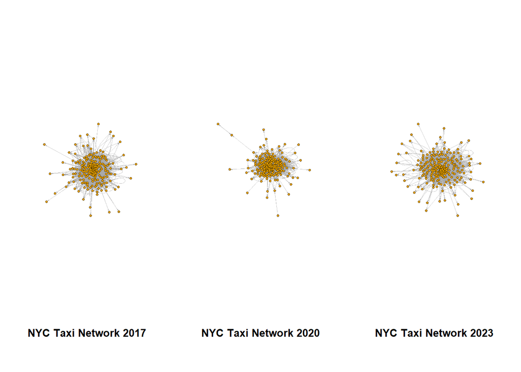

Figure 8: Taxi Network maps from 2017,2020 and 2023 combined to visualise easier

```r
combined_plot <- grid.arrange(g_2017_labeled, g_2020_labeled, g_2023_labeled, ncol = 3)
```

From table 4,5 and 6 we can see the centrality measures for each of the nodes. The ones of specific importance when understanding this network are the overall degree of centrality and the betweenness centrality. The degree of centrality represents the number of links one node has with other nodes within the network (Ergün and Usluel, 2016) in this case it would be how interconnected these locations are. The higher the degree of centrality suggests the more significant a network is. In comparison, betweenness centrality represents the nodes which lay on a path which is connecting other nodes. The higher the betweenness centrality means these nodes have more influence than others.

### Discussion

Not only does COVID-19 directly influence the network by reducing the number of passengers, but it will have a further effect on those who rely on these passengers for their livelihood such as the taxi drivers. By understanding these network measures and where different clusters are within New York, councils can help to mitigate changes to these networks to help increase incentives to use them. For example, if fewer people are using taxis, those in charge of the transport network can introduce easier ways to get taxis or offer promotions to try to increase those travelling in a certain area. It is important for people in the future to measure transport networks if there is a significant cluster in a certain area of New York City with significant passengers and edges, transport companies can try and increase the number of taxis in that area to further help the network.

Overall, the data shows that the network of New York Taxi data has changed since 2017, and it is predominately because of COVID-19 and the increase of people working from home. This is not to say that this has changed for the worse, instead it is different, and the network changed to support the different needs of the area. The data shows also that even though the network has changed there are still a significant number of nodes and people using Yellow Taxi Cabs, as mentioned before this is because they are a pinnacle part of New York history. However, it is important to remember that this data is only representative of one day in one month. In the future, it is suggested to use a bigger data set of all the months and instead focus on a specific area of New York City. In the future, this data can also be combined with data such as where businesses are located or other commuting networks such are the subway to see if other forms of transport networks have been influenced similarly.

### Conlusions

In conclusion, networks are subject to change because the world around us is always changing. COVID-19 has influenced the network structure of New York Taxis by changing where different clusters are gathering. However, network changes are not always a bad thing as this can introduce new variables into a network and can cause the network to expand. But it is increasingly important to preserve the New York Taxi network as it is the backbone of the city and is a fundamental part of the history. This research has shown that the network of New York Yellow Taxis is still relied on heavily and should be preserved.

### References

Abduljabbar, R.L., Liyanage, S. and Dia, H. (2022) ‘A systematic review of the impacts of the coronavirus crisis on urban transport: Key lessons learned and prospects for future cities’, Cities, 127, pp. 103770. doi: 10.1016/j.cities.2022.103770.

Arimura, M., Ha, T.V., Okumura, K. and Asada, T. (2020) ‘Changes in urban mobility in Sapporo city, Japan due to the Covid-19 emergency declarations’, Transportation Research Interdisciplinary Perspectives, 7, pp. 100212. doi: 10.1016/j.trip.2020.100212.

Batty, M. (2013) The New Science of Cities. Cambridge: MIT Press.

Ergün, E. and Usluel, Y.K. (2016) ‘An analysis of density and degree-centrality according to the social networking structure formed in an online learning environment’, Journal of Educational Technology & Society, 19(4), pp. 34–46.

Fang, C., Yu, X., Zhang, X., Fang, J. and Liu, H. (2020) ‘Big data analysis on the spatial networks of urban agglomeration’, Cities, 102, pp. 102735. doi: 10.1016/j.cities.2020.102735.

Gandhi, S.J., Gorod, A. and Sauser, B. (2011) A case study: the New York city yellow cab system of systems. IEEE, pp. 282.

Hamedmoghadam-Rafati, H., Steponavice, I., Ramezani, M. and Saberi, M. (2017) ‘A complex network analysis of macroscopic structure of taxi trips’, IFAC-PapersOnLine, 50(1), pp. 9432–9437.

Johansson, B. and Quigley, J.M. (2004) Agglomeration and networks in spatial economies. Springer.

N. Ferreira, J. Poco, H. T. Vo, J. Freire and C. T. Silva (2013) ‘Visual Exploration of Big Spatio-Temporal Urban Data: A Study of New York City Taxi Trips’, IEEE Transactions on Visualization and Computer Graphics, 19(12), pp. 2149–2158. doi: 10.1109/TVCG.2013.226.

Nian, G., Peng, B., Sun, D., Ma, W., Peng, B. and Huang, T. (2020) ‘Impact of COVID-19 on urban mobility during post-epidemic period in megacities: From the perspectives of taxi travel and social vitality’, Sustainability, 12(19), pp. 7954.

Pflieger, G. and Rozenblat, C. (2010) ‘Introduction. Urban networks and network theory: the city as the connector of multiple networks’, Urban Studies, 47(13), pp. 2723–2735.

Ulak, M.B., Yazici, A. and Aljarrah, M. (2020) ‘Value of convenience for taxi trips in New York City’, Transportation Research Part A: Policy and Practice, 142, pp. 85–100. doi: 10.1016/j.tra.2020.10.016.

Willis, G. and Tranos, E. (2021) ‘Using ‘Big Data’ to understand the impacts of Uber on taxis in New York City’, Travel Behaviour and Society, 22, pp. 94–107. doi: 10.1016/j.tbs.2020.08.003.